# 03_analysis: 模拟数据与基础分析

**学生**：谢婧怡 25210094

说明：本 Notebook 包含题目要求的描述性统计与可视化。

计算并呈现 `df` 的描述性统计量（包括偏度与峰度）。

```
Using base: .
Loaded rows: 15317 source: combined_data
       industry  ann_mean   ann_vol      skew   kurtosis  max_drawdown
code
2       Unknown -0.323163  0.363877  0.655188   6.252892      0.865329
625     Unknown  0.102394  0.480113  0.321766   5.139187      0.599559
858     Unknown -0.012962  0.345522  0.087525   6.297293      0.660949
2352    Unknown -0.000904  0.322506  0.324879   6.384748      0.707728
600028  Unknown  0.084749  0.233562  0.360311   8.343976      0.250772
600050  Unknown -0.024252  0.289842  0.906455  10.525832      0.436923
600104  Unknown -0.060234  0.317197  0.337150   8.254041      0.539805
600519  Unknown  0.066559  0.277019  0.261509   6.598653      0.474822
601398  Unknown  0.094987  0.163070  0.453762   8.778584      0.201681
601988  Unknown  0.134019  0.164462  0.686151  12.064382      0.171026
Macro columns: ['商品', '日期', '今值', '预测值', '前值']
Macro loaded: 68 rows, date range 2020-01-09 00:00:00 to 2025-08-09 00:00:00
HS300 monthly returns: 75 months, range 2020-02-29 00:00:00 to 2026-04-30 00:00:00
Overlapping monthly data points: 67
Fig4 saved successfully
Figures saved to .\output
```

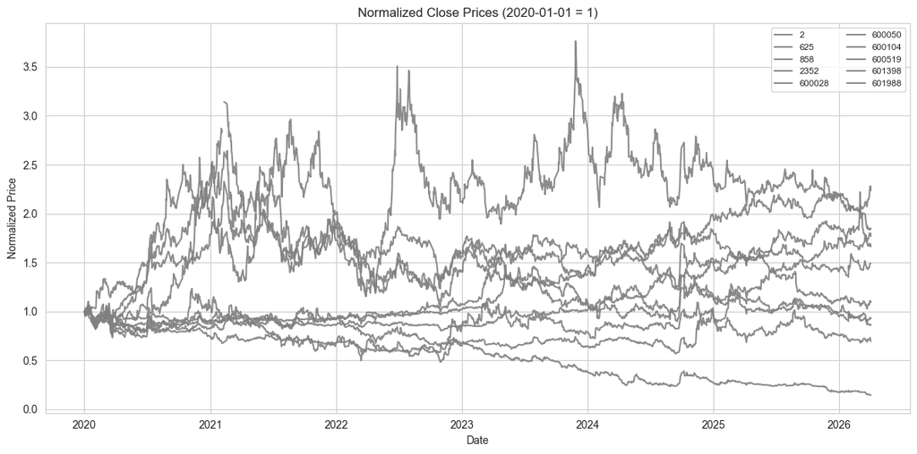

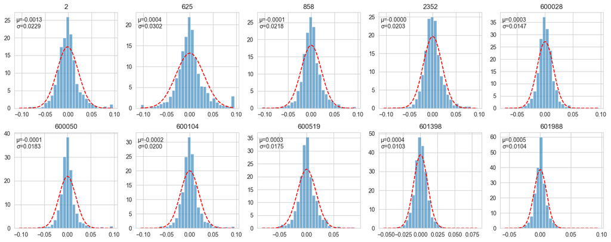

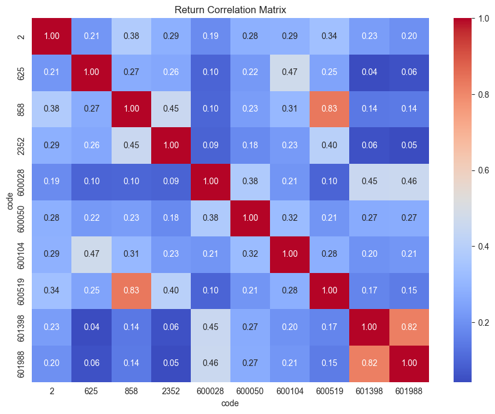

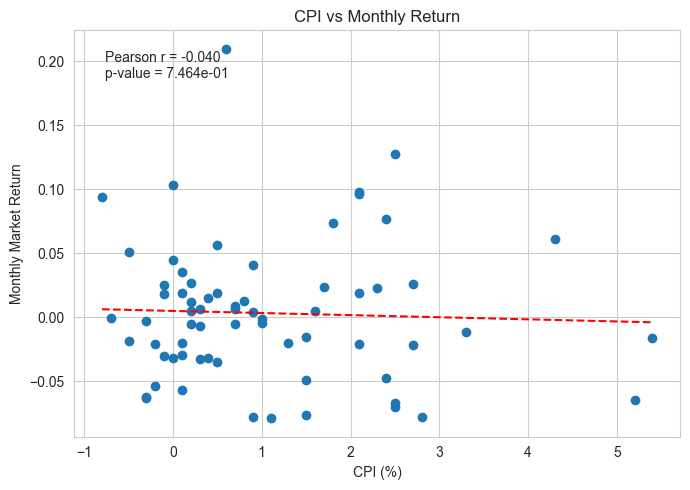

## 图 1：归一化收盘价走势图

[figure not shown]

此外，若多只同一行业股票的曲线走向一致，说明该行业受到共同驱动因子的影响；单只股票的异常波动可能提示公司特有事件或估值修正。

## 图 2：日收益率分布图（2×5 面板）

[figure not shown]

图2 为 10 只股票的日收益率直方图（每子图叠加正态拟合曲线），图中每个子图标注了样本均值与标准差，用以观察收益率的集中趋势与波动尺度。若直方分布出现厚尾或两侧尾部高于正态曲线，说明收益率具有显著的非正态性和更高的极端风险。

[figure not shown]

## 图 4：宏观指标（CPI）与沪深300 月度收益率关系

[figure not shown]

图4 为所选宏观指标（CPI）与沪深300 月度收益率的散点图并叠加线性拟合线，图中标注的 Pearson 相关系数描述了两者的线性相关强度与方向。相关系数的正负表示关系方向（正相关或负相关），其经济含义需结合宏观情景解释，例如通胀上升可能压缩估值或触发货币政策收紧，从而影响股市表现。

## 5 回归分析：CAPM 与宏观回归（可选）

```
Market returns computed from HS300: 1512 observations
```

| stock | industry | alpha | alpha_p | beta | beta_ci_lower | beta_ci_upper | r2 |
| --- | --- | --- | --- | --- | --- | --- | --- |
| 2 | Unknown | -0.001316 | 0.009100 | 1.002186 | 0.918905 | 1.085468 | 0.269535 |
| 625 | Unknown | 0.000359 | 0.600752 | 1.202966 | 1.089586 | 1.316346 | 0.222906 |
| 858 | Unknown | -0.000083 | 0.833568 | 1.294335 | 1.228787 | 1.359883 | 0.498386 |
| 2352 | Unknown | -0.000014 | 0.974957 | 0.870046 | 0.795427 | 0.944664 | 0.257800 |
| 600028 | Unknown | 0.000278 | 0.442247 | 0.365655 | 0.305894 | 0.425416 | 0.087088 |
| 600050 | Unknown | -0.000159 | 0.702910 | 0.712681 | 0.643875 | 0.781488 | 0.214682 |
| 600104 | Unknown | -0.000283 | 0.523608 | 0.851155 | 0.777864 | 0.924446 | 0.255763 |
| 600519 | Unknown | 0.000213 | 0.524543 | 0.977542 | 0.922113 | 1.032971 | 0.442129 |
| 601398 | Unknown | 0.000316 | 0.216191 | 0.221825 | 0.179644 | 0.264006 | 0.065831 |
| 601988 | Unknown | 0.000473 | 0.066969 | 0.217570 | 0.174964 | 0.260176 | 0.062306 |

5.1 CAPM 分析结论

其中 1 只股票的 alpha 在 5% 水平上显著：2。显著的 alpha 意味着在 CAPM 控制市场风险后，这些股票存在系统性之外的超额收益/亏损，可能反映公司特有的信息或模型遗漏的风险因子。

R^2 最高的是 858（R^2=0.498），最低的是 601988（R^2=0.062）。R^2 高的股票其收益更多被市场因子解释，通常为行业/系统性风险占优的股票；R^2 低的股票可能受公司特有事件或噪声影响更大。

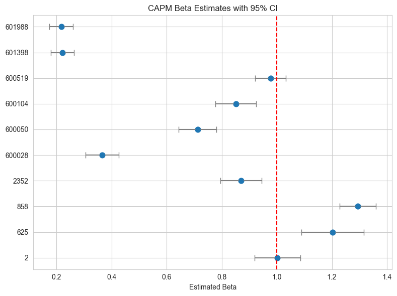

```
✅ 报告已生成: c:\Users\Lenovo\Documents\GitHub\homework\dshw-p01\report.html
```